# Activity Monitoring Devices(Steps)

## Loading and processing data

1. Reading in the data file

```r
setwd("F:\\Coursera\\Course 5 Reproducible Research\\Project 1\\uploadproj1\\RepData_PeerAssessment1")
step_data <- read.csv("activity.csv", stringsAsFactors = FALSE)
step_data$date <- as.Date(step_data$date, format = "%Y-%m-%d")
```

2. Transforming Data and making it more suitable for analysis

```r
# removing NA values
clean_step_data <- subset(step_data, !is.na(step_data$steps))
```

## What is the mean total number of steps taken per day?

1. Calculate the total number of steps taken per day

```r
# code getting total number of steps taken each day
sum_steps <- aggregate(steps ~ date, data = clean_step_data, sum)
```

2. Make a histogram of the total number of steps taken per day

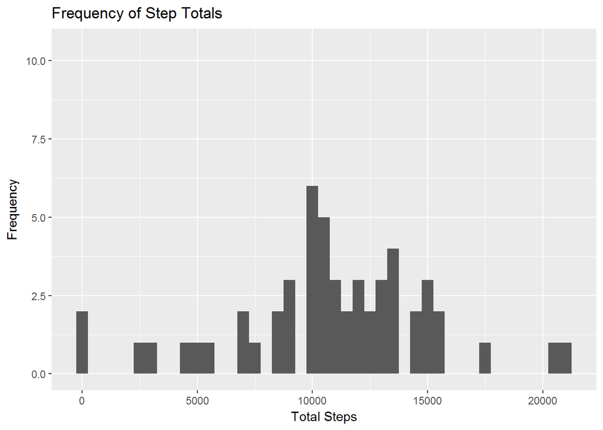

```r
library(ggplot2)
# making histogram using ggplot2
g<- ggplot(data = sum_steps, aes(sum_steps$steps))
        g + geom_histogram(binwidth = 500) +
        labs(title = "Frequency of Step Totals", x = "Total Steps", y= "Frequency") +
        ylim(0,10.5)
```

3. Calculate and Report the mean and median of the total number of steps taken per day

```r
overall_mean <- mean(sum_steps$steps)
overall_median <- median(sum_steps$steps)
overall_mean
```

```
## [1] 10766.19
```

```r
overall_median
```

```
## [1] 10765
```

The mean is 1.076618910^{4}. The median is 10765.

## What is the average daily activity pattern?

1. Make a time series plot of th e 5-minute interval and average number of steps taken averaged across all days

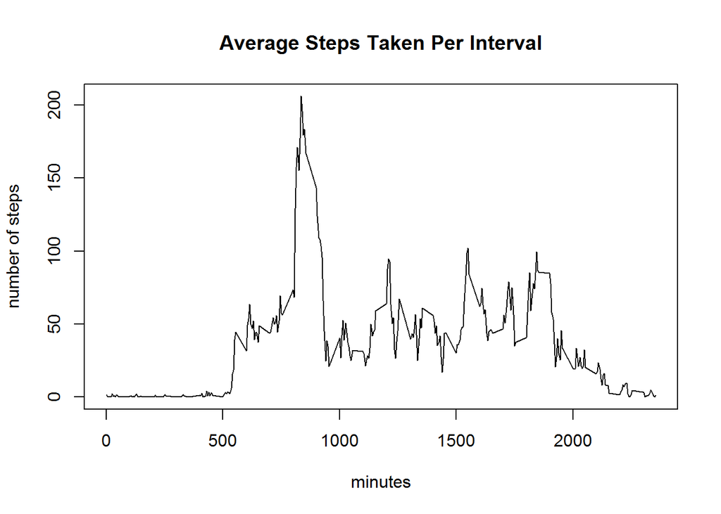

```r
# finding mean number of steps for each interval
mean_steps_int <- aggregate(steps ~ interval, data = clean_step_data, mean)
# making plot of average steps taken per interval
with(mean_steps_int, plot(interval, steps, type = "l",
        main = "Average Steps Taken Per Interval",
        xlab = "minutes", ylab = "number of steps"))
```

2. Which 5 minute interval, on average across all the days in the dataset contains the maximum number of steps?

```r
interval_steps <- aggregate(steps ~ interval, data = step_data, na.action = na.pass, na.rm = TRUE, mean)
max_steps <- max(interval_steps$steps)
maxint <- subset(interval_steps, steps == max_steps)$interval
```

Interval 835 has the maximum number of steps on average.

## Imputting missing values

1. Calculate and report the total number of missing values in the dataset

```r
missingsteps <- sum(is.na(step_data$steps))
```

There are 2304 missing steps in the dataset.

2. Getting values to replace all missing values in the dataset The strategy I chose was to replace all missing values with the average value for that interval. The value was found using the getMeansteps function.

```r
# Function for getting mean steps in an interval
getMeanSteps <- function(interval){
        interval_steps[interval_steps$interval == interval,]$steps
}
```

3. Creating a new dataset equal to the original dataset but with missing data filled in.

```r
# loops through data set and replaces all NA's with mean for the
# corresponding interval
for(i in 1:nrow(step_data)){
        if(is.na(step_data[i,]$steps)){
                step_data$steps[i] <- getMeanSteps(step_data$interval[i])
        }
}
```

4. Making a histogram of the total number of steps taken each day and Calculating and Reporting the mean and median total number of steps per day.

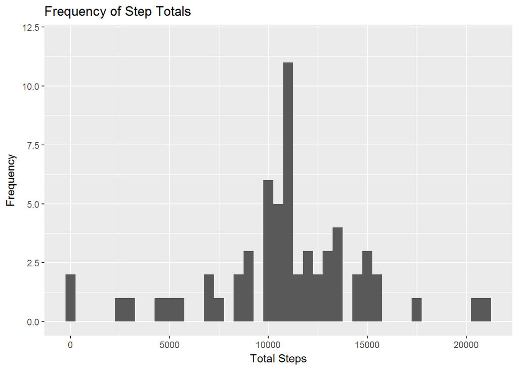

```r
library(ggplot2)
# code getting total number of steps taken each day
sum_steps_nomiss <- aggregate(steps ~ date, data = step_data, sum)


# making histogram
g<- ggplot(data = sum_steps_nomiss, aes(sum_steps_nomiss$steps))
g + geom_histogram(binwidth = 500) + ylim(0,12) +
        labs(title = "Frequency of Step Totals", x = "Total Steps", y= "Frequency")
```

```r
# Calculating Mean total number of steps per day
new_mean <- mean(sum_steps_nomiss$steps)
new_median <- median(sum_steps_nomiss$steps)
new_mean
```

```
## [1] 10766.19
```

```r
new_median
```

```
## [1] 10766.19
```

The original mean is 1.076618910^{4}. The original median is 10765. Then we replaced the NAs with the mean for each interval. The new mean is 1.076618910^{4} and the new median is 1.076618910^{4}.

After replacing the missing values with the average for their corresponding interval, the mean stayed the same and the median increased by 1.

In the histograms the data is less skewed and more normally distributed around the mean after the missing values are replaced.

## Are there differences in the activity patterns between weekends and weekdays?

1. Adding a new varialbe to step_data to determine if observations are on a weekday or weekend. Then finding mean for each interval for weekends and weekdays.

```r
# creating factor variable showing whether day is a weekday
step_data$weekend <- weekdays(step_data$date) %in% c("Saturday", "Sunday")

# relabeling TRUE with weekend False with Weekday
for (i in 1: nrow(step_data)){
        if(step_data$weekend[i] == TRUE){
                step_data$weekend[i] <- "Weekend"
        } else if (step_data$weekend[i] == FALSE){
                step_data$weekend[i]<- "Weekday"
        }
}

# getting averages for weekend intervals and weekday intervals
dow_means <- aggregate(steps ~ interval + weekend, step_data, mean)
```

2. Making a panel plot containing a time series plot of average number of steps taken, where interval is the time used.

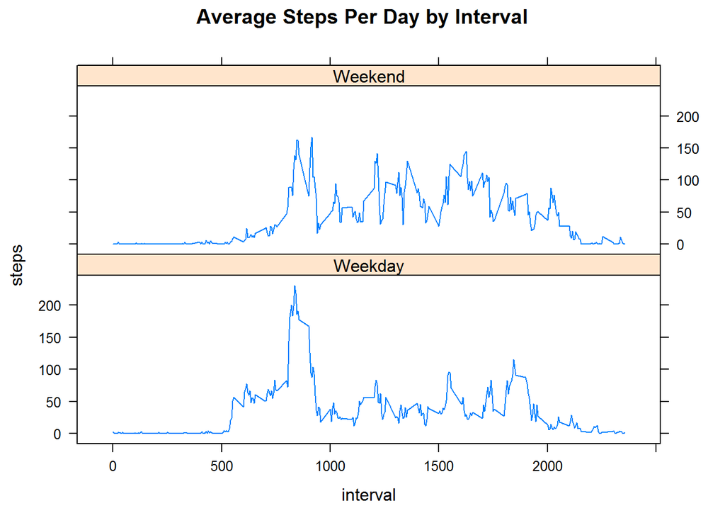

```r
library(lattice)
xyplot(steps ~ interval| weekend, data = dow_means, type = 'l', layout = c(1,2),
       main = "Average Steps Per Day by Interval")
```